# Modeling and prediction for movies

## Setup

### Load packages

```r
library(ggplot2)
library(dplyr)
library(statsr)
library(corrplot)
library(gvlma)
library(knitr)
```

### Load data

```r
#load("movies.Rdata")
```

## Part 1: Data

The data set is comprised of 651 randomly sampled movies produced and released before 2016. random sampling indicates that this is an observational study; the information was collected from randomly sampled movies. Therefore, the sample size dealt in the below research question indicates that the study is generalizable to the population of interest (movies produced and released before 2016). On the other hand, since observational studies do not control any confounding variable, cause-and-effect conclusions between variables cannot be made based on the data.

Since the fact that independent random sampling was used to collect the data set and observations consist of fewer than 10% of the population ensures that the sample observations are independent. We can assume that the population distribution is not strongly skewed taking into a ccount the generalizability of the data mentioned above. Also, there are more than 30 independent observations. All these satisfied conditions allow us to use statistical inference when answering below research question.

However, since this data was gathered from the websites and platforms in which the official language is English, the data might only reflect the opinions of English-speaking people.

## Part 2: Research question

The question is designed to study how audience score on Rotten Tomatoes (the variable ‘audience_score’) is related to relatively ‘intrinsic’ characteristics of movie such as, genre (the variable ‘genre’) and MPAA rating (the variable ‘mpaa_rating’), duration of movie (the variable ‘runtime’) and month it was released (the variable ‘thtr_rel_month’). Especially, I would like to see mpaa rating is a significant predictor of how audience scores a movie, given other intrinsic characteristics of movie variables (genre, runtime, and released month). This is because I am curious to explore that whether a sensational movie tends to have a better score due violent and sensational scenes.

## Part 3: Exploratory data analysis

First and foremost, I decided to simplify several variables by combining 2-3 levels in those variables since some variables have too much levels in one variable or include some unnnecessary levels to answer the above research question.

I only considered the filiming style of “Feature Film” under the variable ‘title_type’ since movie types of Documentary and TV Movie are not likely to be shown in a typical movie theater. Thus, I dropped “Documentary” and “TV Movie” levels from the variable.

```r
movies <- movies %>%
filter(title_type != "Documentary", title_type != "TV Movie") %>%
droplevels()
```

Second, I studied two explanatory variables (‘genre’ and ‘mpaa_rating’). I decided to simplify these variables by combining 2-3 related categories into 1 and dropping some categories.

Under the variable ‘genre’ there are 11 categories. Below table shows the genres of movies in descending order.

```r
movies %>%
count(genre) %>%
arrange(desc(n)) %>%
group_by(genre)
```

```
## # A tibble: 11 x 2
## # Groups: genre [11]
##    genre                         n
##    <fct>                     <int>
##  1 Drama                       301
##  2 Comedy                       85
##  3 Action & Adventure           65
##  4 Mystery & Suspense           59
##  5 Horror                       23
##  6 Other                        15
##  7 Art House & International    14
##  8 Animation                     9
##  9 Science Fiction & Fantasy     9
## 10 Musical & Performing Arts     8
## 11 Documentary                   3
```

```r
movies <- movies %>%
mutate(genre_new = ifelse(genre == "Action & Adventure","A&A",
ifelse(genre == "Horror", "H,M&S",
ifelse(genre == "Mystery & Suspense", "H,M&S",
ifelse(genre == "Science Fiction & Fantasy", "SFF", ifelse(genre == "Drama", "DC&D", ifelse(genre == "Art House & International", "AH&I", ifelse(genre == "Animation", "Ani", ifelse(genre == "Documentary", "DC&D", ifelse(genre == "Comedy", "DC&D", ifelse(genre == "Musical & Performing Arts", "MPA", NA)))))))))))
```

After making a new variable, I checked whether the variable was created successfully with a bar chart.

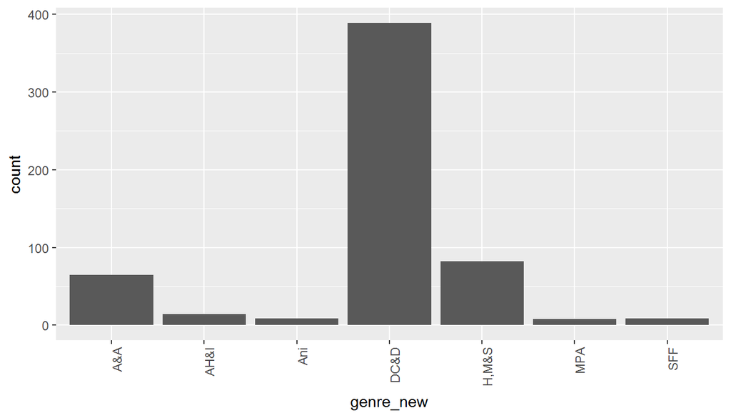

```r
movies %>%
filter(!(is.na(genre_new))) %>%
ggplot(aes(x = genre_new)) + geom_bar() + theme(axis.text.x = element_text(angle = 90, hjust = 1))
```

I also made a count table to see exactly how many observations are in each genre. We can see that Drama, Comedy and Documentry genre has over half of the observations.

```r
movies %>%
filter(!is.na(genre_new)) %>%
group_by(genre_new) %>%
summarise(count = n()) %>%
arrange(desc(count))
```

```
## # A tibble: 7 x 2
##   genre_new count
##   <chr>     <int>
## 1 DC&D        389
## 2 H,M&S        82
## 3 A&A          65
## 4 AH&I         14
## 5 Ani           9
## 6 SFF           9
## 7 MPA           8
```

I explored another explanatory variable “mpaa_rating”. Under this variable, there are 6 categories, which are R, PG-13, PG, G, unrated, NC-17.

```r
movies %>%
count(mpaa_rating) %>%
arrange(desc(n)) %>%
group_by(mpaa_rating)
```

```
## # A tibble: 6 x 2
## # Groups: mpaa_rating [6]
##   mpaa_rating     n
##   <fct>       <int>
## 1 R             317
## 2 PG-13         130
## 3 PG            110
## 4 G              16
## 5 Unrated        16
## 6 NC-17           2
```

Also to simplify our data analaysis, I crated a new variable ‘mpaa_new’ to drop levels such as ‘unrated’ and ‘NC-17’ because they are not likely to be shown in a typical movie theater.

```r
movies <- movies %>%
mutate(mpaa_new = ifelse(mpaa_rating == "R","R",
ifelse(mpaa_rating == "PG-13", "PG-13",
ifelse(mpaa_rating == "PG", "PG", ifelse(mpaa_rating == "G", "G", NA)))))
```

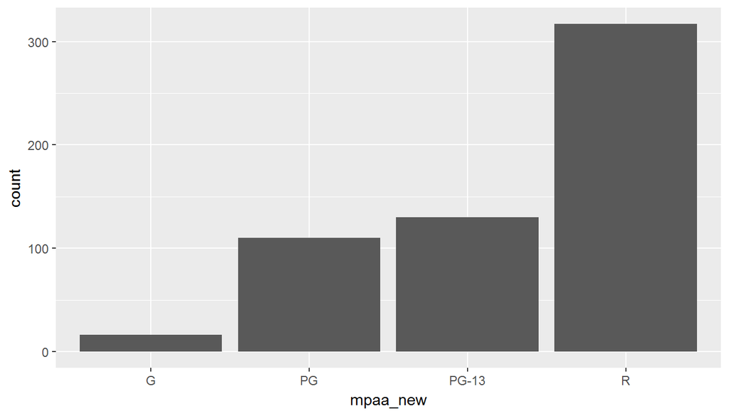

```r
movies %>%
filter(!(is.na(mpaa_new))) %>%
ggplot(aes(x = mpaa_new)) + geom_bar()
```

For the variable ‘thtr_rel_month’, which shows released month of movies in theater, I first made a table to see overall trend, and made a new variable ‘season’ in order to distinguish months by seasons. 69 movies are released in June, then 65 movies in December and 62 movies in October. We can see that overall, observations are spreaded out relatively evenly over a full year 2016.

```r
movies %>%
count(thtr_rel_month) %>%
arrange(desc(n)) %>%
group_by(thtr_rel_month)
```

```
## # A tibble: 12 x 2
## # Groups: thtr_rel_month [12]
##    thtr_rel_month     n
##             <dbl> <int>
##  1           6.00    69
##  2          12.0     65
##  3          10.0     62
##  4           1.00    60
##  5          11.0     49
##  6           3.00    47
##  7           7.00    45
##  8           9.00    45
##  9           5.00    41
## 10           4.00    40
## 11           8.00    39
## 12           2.00    29
```

I made the ‘season’ variable and grouped November and December as “Holiday”, January and February as “Winter”, March, April, and May as “Spring”, June, July and August as “Summer”, and September and October as “Fall”.

```r
movies <- movies %>%
mutate(season = ifelse(thtr_rel_month >= 11 ,"Holiday",
ifelse(thtr_rel_month <=2, "Winter",
ifelse(thtr_rel_month <=5, "Spring",
ifelse(thtr_rel_month <= 8, "Summer", ifelse(thtr_rel_month <= 10, "Fall", NA))))))
```

Then, I checked with the bar chart below to see whether different seasons were well created under the variable.

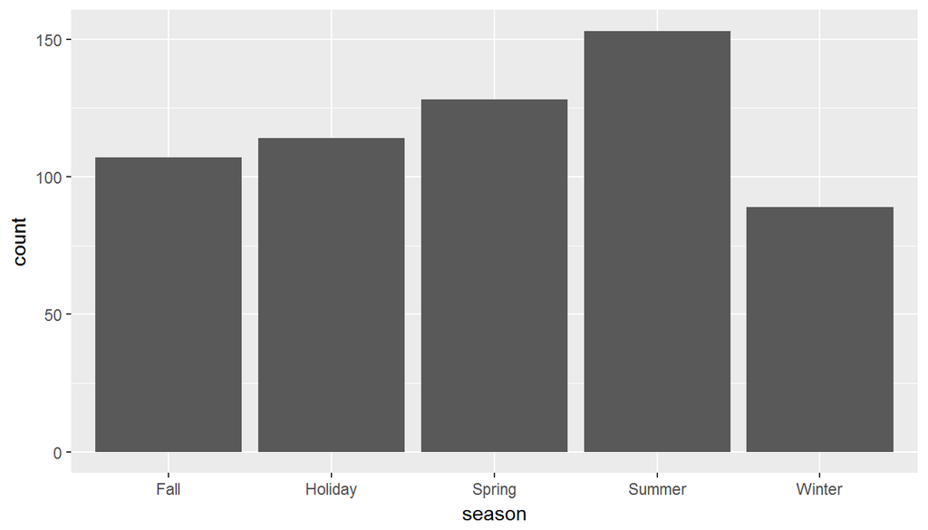

```r
movies %>%
ggplot(aes(x = season)) + geom_bar()
```

With the count function of ‘season’, we can see that most movies are released in Summer. Also, there are significant numbers of movies released in Spring and holiday season.

```r
movies %>%
count(season) %>%
arrange(desc(n)) %>%
group_by(season)
```

```
## # A tibble: 5 x 2
## # Groups: season [5]
##   season      n
##   <chr>   <int>
## 1 Summer    153
## 2 Spring    128
## 3 Holiday   114
## 4 Fall      107
## 5 Winter     89
```

The other explanatory variable ‘runtime’ shows runtime of movie in minutes. I made a summary table in order to explore further this numerical variable. With the below table, I can see that mean is 106.6 minutes and median is 104 minutes. The difference between the two measures is small.

```r
with(movies, summary(runtime))
```

```
##    Min. 1st Qu.  Median    Mean 3rd Qu.    Max.
##    68.0    93.0   104.0   106.6   116.0   202.0
```

Now, I checked with the histogram for this variable. We can see that although median and mean are relatively close to each other, due to outliers the histogram shows a right-skewness.

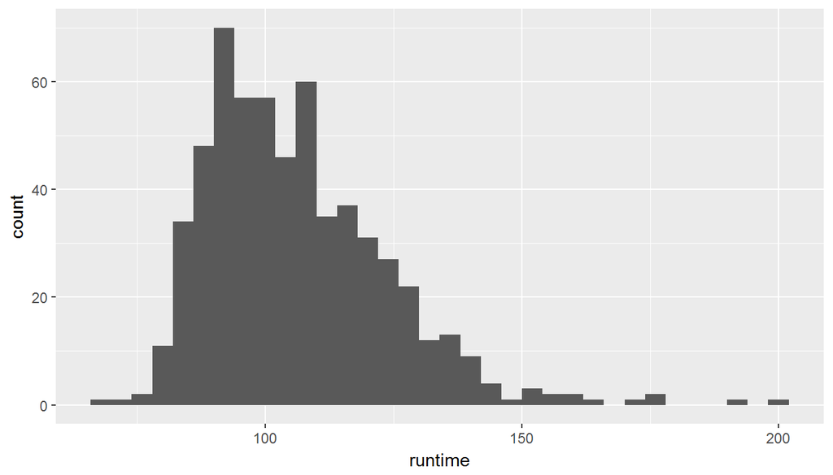

```r
ggplot(movies, aes(x = runtime)) + geom_histogram(binwidth = 4)
```

```r
with(movies, summary(audience_score))
```

```
##    Min. 1st Qu.  Median    Mean 3rd Qu.    Max.
##   11.00   44.50   62.00   60.47   78.00   97.00
```

Then I made a histogram to see the distribution of the variable. Audience scores show a fairly normal but showing multimodal distribtuion.

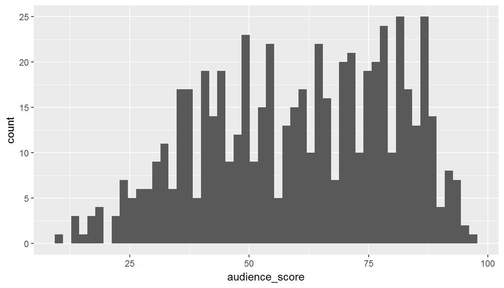

```r
ggplot(movies, aes(x = audience_score)) + geom_histogram(binwidth = 1.7)
```

With the above selected variables, I created a new dataframe movies_characteristics and named it as movies2.

```r
movies_characteristics <- c("audience_score", "genre_new", "mpaa_new", "runtime", "season")
movies2 <-movies[movies_characteristics]
summary(movies2)
```

```
##  audience_score   genre_new           mpaa_new            runtime
##  Min.   :11.00   Length:591         Length:591         Min.   : 68.0
##  1st Qu.:44.50   Class :character   Class :character   1st Qu.: 93.0
##  Median :62.00   Mode  :character   Mode  :character   Median :104.0
##  Mean   :60.47                                         Mean   :106.6
##  3rd Qu.:78.00                                         3rd Qu.:116.0
##  Max.   :97.00                                         Max.   :202.0
##     season
##  Length:591
##  Class :character
##  Mode  :character
##
##
##
```

Then, I checked the levels of each variable we are interested in.

```r
str(movies2)
```

```
## Classes 'tbl_df', 'tbl' and 'data.frame':    591 obs. of  5 variables:
##  $ audience_score: num  73 81 91 76 27 76 47 66 75 46 ...
##  $ genre_new     : chr  "DC&D" "DC&D" "DC&D" "DC&D" ...
##  $ mpaa_new      : chr  "R" "PG-13" "R" "PG" ...
##  $ runtime       : num  80 101 84 139 90 142 93 119 127 108 ...
##  $ season        : chr  "Spring" "Spring" "Summer" "Fall" ...
```

Now in order to see how each chosen explanatory variable is correlated to the chosen response variable ‘audience_score’, I created boxplots.

First, with the categorical variable ‘genre_new’ and the numerical response variable ‘audience_score’, I made a boxplot.

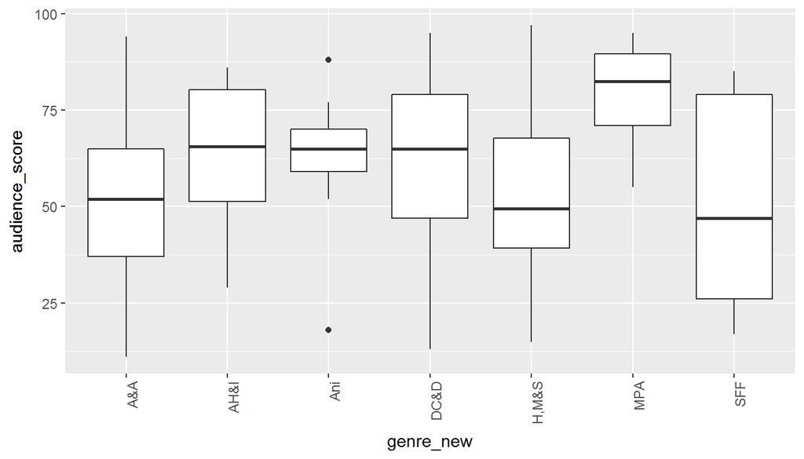

```r
movies2 %>%
filter(!(is.na(genre_new))) %>%
ggplot(aes(x = genre_new, y = audience_score)) + geom_boxplot() + theme(axis.text.x = element_text(angle = 90, hjust = 1))
```

```r
with(movies2, by(audience_score, genre_new, summary))
```

```
## genre_new: A&A
##    Min. 1st Qu.  Median    Mean 3rd Qu.    Max.
##   11.00   37.00   52.00   53.78   65.00   94.00
## --------------------------------------------------------
## genre_new: AH&I
##    Min. 1st Qu.  Median    Mean 3rd Qu.    Max.
##   29.00   51.25   65.50   64.00   80.25   86.00
## --------------------------------------------------------
## genre_new: Ani
##    Min. 1st Qu.  Median    Mean 3rd Qu.    Max.
##   18.00   59.00   65.00   62.44   70.00   88.00
## --------------------------------------------------------
## genre_new: DC&D
##    Min. 1st Qu.  Median    Mean 3rd Qu.    Max.
##   13.00   47.00   65.00   62.43   79.00   95.00
## --------------------------------------------------------
## genre_new: H,M&S
##    Min. 1st Qu.  Median    Mean 3rd Qu.    Max.
##   15.00   39.25   49.50   53.11   67.75   97.00
## --------------------------------------------------------
## genre_new: MPA
##    Min. 1st Qu.  Median    Mean 3rd Qu.    Max.
##   55.00   71.00   82.50   79.38   89.50   95.00
## --------------------------------------------------------
## genre_new: SFF
##    Min. 1st Qu.  Median    Mean 3rd Qu.    Max.
##   17.00   26.00   47.00   50.89   79.00   85.00
```

Second, I visualized the relationship between the explanatory categorical variable ‘mpaa_new’ and the numerical response variable ‘audience_score’. Unlike genre boxplot, the each level of mpaa rating variable is fairly similar to one another.

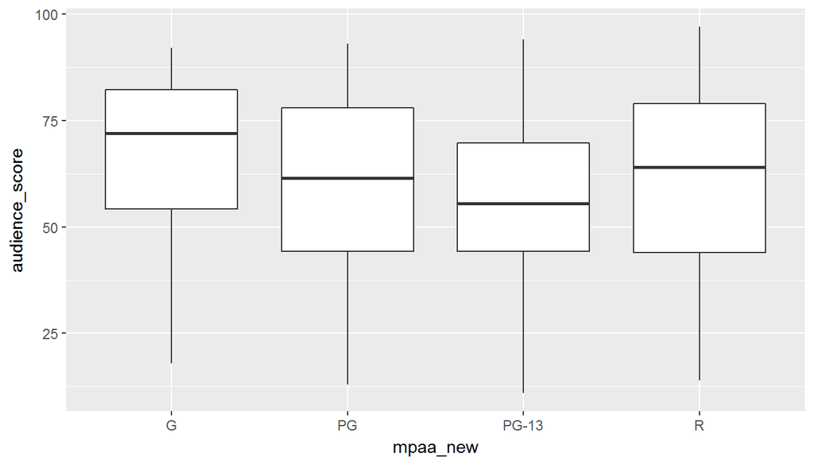

```r
movies2 %>%
filter(!(is.na(mpaa_new))) %>%
ggplot(aes(x = mpaa_new, y = audience_score)) + geom_boxplot()
```

The summary table below shows that there is not so significance difference in audience score among different levels of mpaa rating. However, mpaa rating ‘G’ has the highest median and mean among all other levels.

```r
with(movies2, by(audience_score, mpaa_new, summary))
```

```
## mpaa_new: G
##    Min. 1st Qu.  Median    Mean 3rd Qu.    Max.
##   18.00   54.25   72.00   66.62   82.25   92.00
## --------------------------------------------------------
## mpaa_new: PG
##    Min. 1st Qu.  Median    Mean 3rd Qu.    Max.
##   13.00   44.25   61.50   60.42   78.00   93.00
## --------------------------------------------------------
## mpaa_new: PG-13
##    Min. 1st Qu.  Median    Mean 3rd Qu.    Max.
##   11.00   44.25   55.50   56.02   69.75   94.00
## --------------------------------------------------------
## mpaa_new: R
##    Min. 1st Qu.  Median    Mean 3rd Qu.    Max.
##   14.00   44.00   64.00   61.45   79.00   97.00
```

Now, the relationship between the explanatory categorical variable ‘season’ and numerical response variable ‘audience_score’ is shown below by the boxplot. The size of each level of the variable season is similar to one another. In addition, means of each level of the variable also is relatively cose to one another.

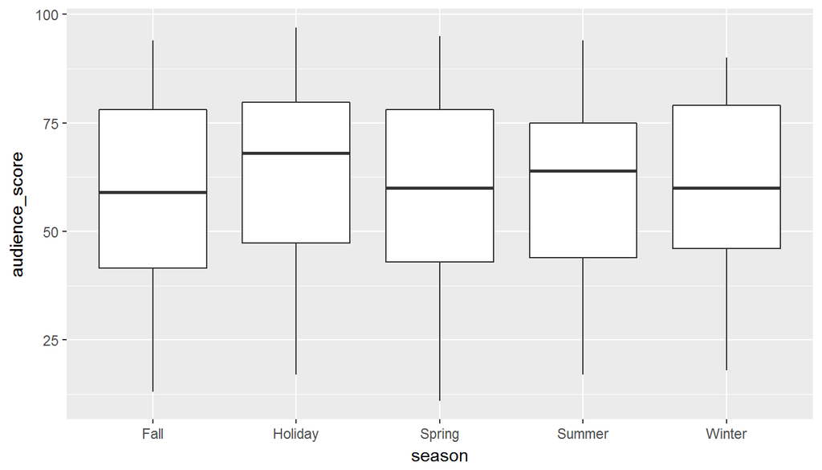

```r
movies2 %>%
ggplot(aes(x = season, y = audience_score)) + geom_boxplot()
```

The summary table below further confirms our observation above that there is not so significance difference in audience score among different seasons. The audience score of the movies released in holiday season has the highest mean with 63.91.

```r
with(movies2, by(audience_score, season, summary))
```

```
## season: Fall
##    Min. 1st Qu.  Median    Mean 3rd Qu.    Max.
##   13.00   41.50   59.00   58.86   78.00   94.00
## --------------------------------------------------------
## season: Holiday
##    Min. 1st Qu.  Median    Mean 3rd Qu.    Max.
##   17.00   47.25   68.00   63.91   79.75   97.00
## --------------------------------------------------------
## season: Spring
##    Min. 1st Qu.  Median    Mean 3rd Qu.    Max.
##   11.00   43.00   60.00   58.78   78.00   95.00
## --------------------------------------------------------
## season: Summer
##    Min. 1st Qu.  Median    Mean 3rd Qu.    Max.
##   17.00   44.00   64.00   60.24   75.00   94.00
## --------------------------------------------------------
## season: Winter
##    Min. 1st Qu.  Median    Mean 3rd Qu.    Max.
##   18.00   46.00   60.00   60.79   79.00   90.00
```

Third, the relationship between the numerical explanatory variable ‘runtime’ and the numerical response variable ’audience_score’is shown below with a scatterplot.

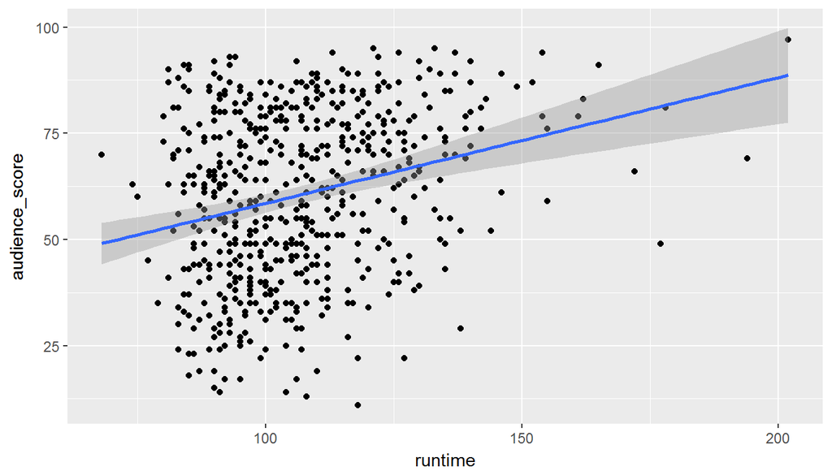

```r
ggplot(movies2, aes(x = runtime, y = audience_score)) + geom_point() + stat_smooth(method = lm, level=0.99)
```

```r
with(movies2, cor(runtime, audience_score))
```

```
## [1] 0.2647005
```

Since all explanatory variables are analyzed and their relationships with the response variable ‘audience_score’ are explored, now I would like to combine all these variables to determine the best model that predicts audience score on Rotten Tomatoes, and also to answer my above mentioned research question whether the mpaa rating of R tends to have higher audience score. * * *

## Part 4: Modeling

As addressed in Part 2: Research Question section, I would like to consider how intrinsic characteristics of movie such as run time, mpaa rating, released month, and genre, contribute to the popularity of movie. Specifically, I would like to find out whether the mpaa rating variable is the strongest predictor variable in predicting audience score. Therefore, I excluded variables that are not ‘natural characteristics’ of movie such as whether a movie got an award, whether the movie, after released, was in the Top 200 Box office, or whether actor/actresses in that movie ever won an Oscar.

In order to separate other ‘non-natural’ characteristics of movie variables from ‘intrinsic’ characteristics of movie, in Part 3, I already made a data set ‘movies2’ which only includes the variables which show natural characteristics of movie.

Moreover, there are other rating variables that we could have considered as response variables such as, rating scores from IMDB and from Rotten Tomatoes critics. However, since those ratings could be colinear to one another, I only considered one rating variable, and I chose the audience score on Rotten Tomatoes which is broader.

I chose the p-value approach for the model selection since I would like to understand which variables are statistically significant predictors of the variable ‘audience_score’. I chose forward selection since we only have 4 predictor variables.

First, I added ‘genre_new’ variable. Below summary shows that ‘Drama, Comedy & Documentary’ genre and ‘Music & Performance Arts’ genre have the significance level less than $\alpha$ = 0.05. Therefore, we include the variable ‘genre_new’.

```r
movies_mlr1 = lm(audience_score ~ genre_new, data = movies2)
summary(movies_mlr1)
```

```
##
## Call:
## lm(formula = audience_score ~ genre_new, data = movies2)
##
## Residuals:
##     Min      1Q  Median      3Q     Max
## -49.434 -14.603   1.215  15.566  43.890
##
## Coefficients:
##                Estimate Std. Error t value Pr(>|t|)
## (Intercept)     53.7846     2.4001  22.410  < 2e-16 ***
## genre_newAH&I   10.2154     5.7013   1.792 0.073703 .
## genre_newAni     8.6598     6.8821   1.258 0.208794
## genre_newDC&D    8.6498     2.5929   3.336 0.000905 ***
## genre_newH,M&S  -0.6749     3.2135  -0.210 0.833737
## genre_newMPA    25.5904     7.2501   3.530 0.000450 ***
## genre_newSFF    -2.8957     6.8821  -0.421 0.674087
## ---
## Signif. codes:  0 '***' 0.001 '**' 0.01 '*' 0.05 '.' 0.1 ' ' 1
##
## Residual standard error: 19.35 on 569 degrees of freedom
##   (15 observations deleted due to missingness)
## Multiple R-squared:  0.05629,    Adjusted R-squared:  0.04634
## F-statistic: 5.657 on 6 and 569 DF,  p-value: 1.011e-05
```

Then, we include the variable which shows mpaa rating. Because only PG-13 level has the significance level less than $\alpha$ = 0.05, we also include this variable to our model.

```r
movies_mlr2 = lm(audience_score ~ genre_new + mpaa_new, data = movies2)
summary(movies_mlr2)
```

```
##
## Call:
## lm(formula = audience_score ~ genre_new + mpaa_new, data = movies2)
##
## Residuals:
##     Min      1Q  Median      3Q     Max
## -49.961 -14.944   1.039  15.849  43.056
##
## Coefficients:
##                Estimate Std. Error t value Pr(>|t|)
## (Intercept)      64.747      5.780  11.203  < 2e-16 ***
## genre_newAH&I     3.057      6.612   0.462 0.643989
## genre_newAni      1.443      7.659   0.188 0.850598
## genre_newDC&D     8.874      2.651   3.347 0.000872 ***
## genre_newH,M&S   -1.144      3.332  -0.343 0.731550
## genre_newMPA     25.416      7.255   3.503 0.000497 ***
## genre_newSFF     -4.093      6.870  -0.596 0.551553
## mpaa_newPG      -11.239      5.844  -1.923 0.055003 .
## mpaa_newPG-13   -15.533      5.924  -2.622 0.008990 **
## mpaa_newR        -9.659      5.801  -1.665 0.096455 .
## ---
## Signif. codes:  0 '***' 0.001 '**' 0.01 '*' 0.05 '.' 0.1 ' ' 1
##
## Residual standard error: 19.29 on 549 degrees of freedom
##   (32 observations deleted due to missingness)
## Multiple R-squared:  0.07476,    Adjusted R-squared:  0.05959
## F-statistic: 4.929 on 9 and 549 DF,  p-value: 2.221e-06
```

Now we add the variable ‘season’ to our model. Since niether level in the variable season has a p-value less than $\alpha$ = 0.05, we exclude the variable ‘season’ from our model.

```r
movies_mlr3 = lm(audience_score ~ genre_new + mpaa_new + season, data = movies2)
summary(movies_mlr3)
```

```
##
## Call:
## lm(formula = audience_score ~ genre_new + mpaa_new + season,
##     data = movies2)
##
## Residuals:
##     Min      1Q  Median      3Q     Max
## -48.121 -14.289   0.677  15.606  41.561
##
## Coefficients:
##                Estimate Std. Error t value Pr(>|t|)
## (Intercept)     62.5431     6.1278  10.207  < 2e-16 ***
## genre_newAH&I    3.5114     6.6271   0.530 0.596428
## genre_newAni     0.5117     7.7131   0.066 0.947127
## genre_newDC&D    8.9581     2.6638   3.363 0.000825 ***
## genre_newH,M&S  -0.7238     3.3534  -0.216 0.829199
## genre_newMPA    25.5271     7.2896   3.502 0.000500 ***
## genre_newSFF    -4.1158     6.8885  -0.597 0.550430
## mpaa_newPG     -11.1533     5.8754  -1.898 0.058183 .
## mpaa_newPG-13  -15.2956     5.9369  -2.576 0.010246 *
## mpaa_newR       -9.3799     5.8202  -1.612 0.107628
## seasonHoliday    3.9332     2.7056   1.454 0.146591
## seasonSpring     0.2209     2.6250   0.084 0.932973
## seasonSummer     2.4776     2.5324   0.978 0.328323
## seasonWinter     2.6931     2.9010   0.928 0.353652
## ---
## Signif. codes:  0 '***' 0.001 '**' 0.01 '*' 0.05 '.' 0.1 ' ' 1
##
## Residual standard error: 19.3 on 545 degrees of freedom
##   (32 observations deleted due to missingness)
## Multiple R-squared:  0.08033,    Adjusted R-squared:  0.0584
## F-statistic: 3.662 on 13 and 545 DF,  p-value: 1.371e-05
```

The final variable ‘runtime’ is added to our model. Since runtime has very small p-value, we include the variable into our model.

```r
movies_mlr_final = lm(audience_score ~ genre_new + mpaa_new + runtime, data = movies2)
summary(movies_mlr_final)
```

```
##
## Call:
## lm(formula = audience_score ~ genre_new + mpaa_new + runtime,
##     data = movies2)
##
## Residuals:
##     Min      1Q  Median      3Q     Max
## -50.413 -14.600   1.732  14.905  38.971
##
## Coefficients:
##                 Estimate Std. Error t value Pr(>|t|)
## (Intercept)     35.25335    7.08025   4.979 8.57e-07 ***
## genre_newAH&I    4.10782    6.36253   0.646 0.518791
## genre_newAni     4.75417    7.38456   0.644 0.519975
## genre_newDC&D    7.95329    2.55373   3.114 0.001940 **
## genre_newH,M&S  -1.50413    3.20543  -0.469 0.639082
## genre_newMPA    21.76905    7.00029   3.110 0.001970 **
## genre_newSFF    -3.52641    6.60949  -0.534 0.593878
## mpaa_newPG     -12.89933    5.62758  -2.292 0.022274 *
## mpaa_newPG-13  -19.27025    5.72620  -3.365 0.000818 ***
## mpaa_newR      -12.05373    5.59161  -2.156 0.031543 *
## runtime          0.30654    0.04556   6.728 4.34e-11 ***
## ---
## Signif. codes:  0 '***' 0.001 '**' 0.01 '*' 0.05 '.' 0.1 ' ' 1
##
## Residual standard error: 18.56 on 548 degrees of freedom
##   (32 observations deleted due to missingness)
## Multiple R-squared:  0.1454, Adjusted R-squared:  0.1298
## F-statistic:  9.32 on 10 and 548 DF,  p-value: 2.418e-14
```

Thus, I selected the final model ‘movie_mlr_final’ which includes the variables that show genre, mpaa rating, and runtime.

This final formula shows a parsimonious model, the simplist model with the highest predictive power with 3 variables ‘genre_new’, ‘mpaa_new’ and ‘runtime’. Below ANOVA table further confirms the significance level of individual predictor variables. Unlike what I expected, runtime is the strongest predictor variable in this model. Mpaa rating is, on the other hand, the weakest predictor variable with p-value of 0.005.

```r
anova(movies_mlr_final)
```

```
## Analysis of Variance Table
##
## Response: audience_score
##            Df Sum Sq Mean Sq F value    Pr(>F)
## genre_new   6  11955  1992.5  5.7851 7.426e-06 ***
## mpaa_new    3   4556  1518.5  4.4088  0.004464 **
## runtime     1  15591 15590.7 45.2656 4.341e-11 ***
## Residuals 548 188746   344.4
## ---
## Signif. codes:  0 '***' 0.001 '**' 0.01 '*' 0.05 '.' 0.1 ' ' 1
```

Now, I would like to run the model diagnostics. There are 4 assuptions that have to be considered when using the final model with multiple regression methods.

1. each numerical variable is linearly related to the outcome. I checked this assuption by using residual plots to see whether numerical explanatory variable (in our model, only the variable ‘runtime’) is linearly related to the response variable ‘audience_score’. Below plot shows that dots are randomly scattered around 0. Most residuals are randomly clustered around run time of 80 minutes to 140 minutes. Therefore, this condition is met.

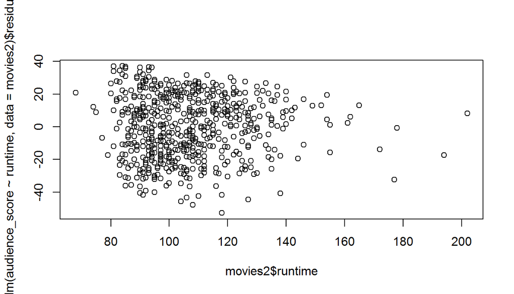

```r
plot(lm(audience_score ~ runtime, data = movies2)$residuals ~ movies2$runtime)
```

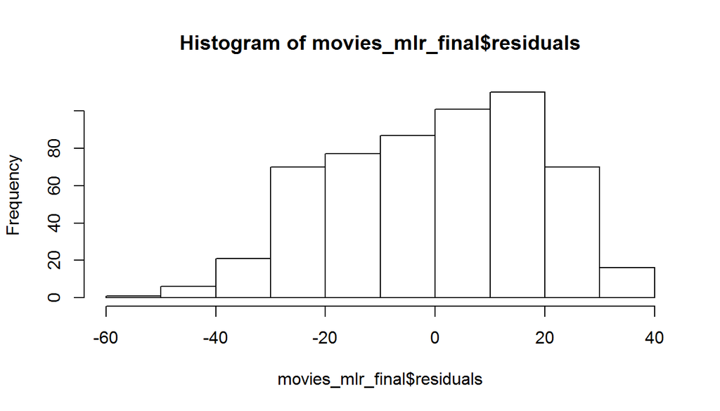

```r
hist(movies_mlr_final$residuals)
```

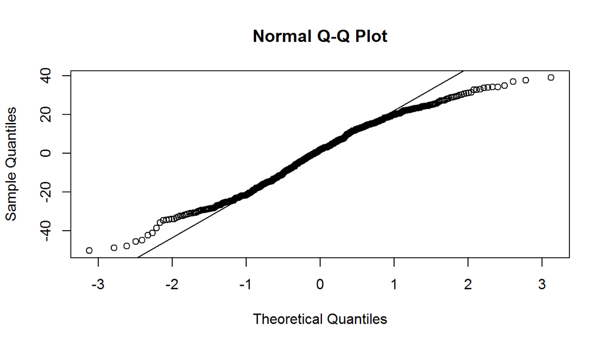

```r
qqnorm(movies_mlr_final$residuals)
qqline(movies_mlr_final$residuals)
```

3. the variability of the residuals are nearly constant In order to see whether residuals are equally variable for low and high values of the predicted response variable, I checked using residual plots of residuals versus predicted value. The residual plot should not show any fan-shaped pattern. I also included absolute value of residuals versus predicted to detect unusual observations easily. It does not seem like the residual plot shows a fan-shaped pattern. Thus, this condition is also met.

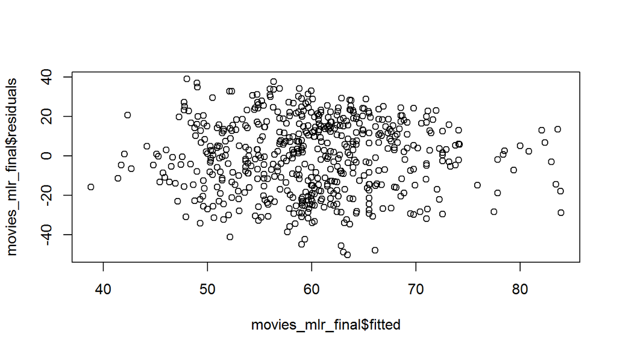

```r
plot(movies_mlr_final$residuals ~ movies_mlr_final$fitted)
```

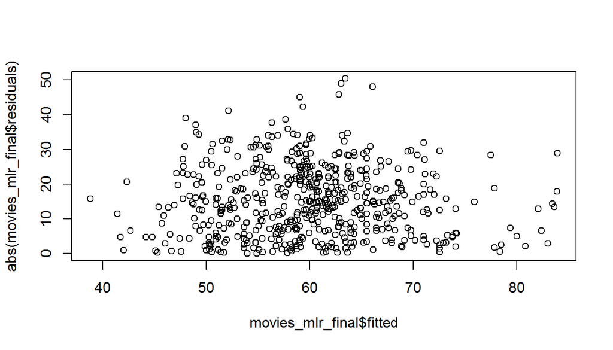

```r
plot(abs(movies_mlr_final$residuals) ~ movies_mlr_final$fitted)
```

4. residuals are independent As discussed in Part 1, the data is collected by random sampling. Also, I checked by plotting the residuals which will appear in the order of data collection. The plot below does not show any patterns. Thus, the condition is also met.

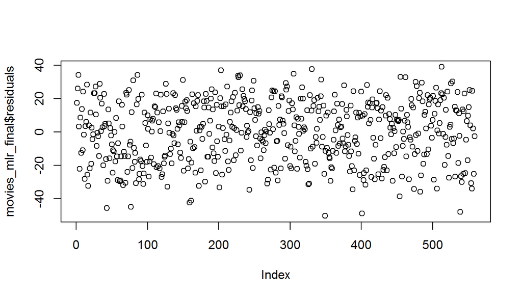

```r
plot(movies_mlr_final$residuals)
```

I used the coefficient command to interpret each coefficient of variables shown in below table. Note that for the categorical variable, the reference level for genre ‘Action & Adventure’ and the reference level for mpaa rating G are not shown below.

```r
coefficients(movies_mlr_final)
```

```
##    (Intercept)  genre_newAH&I   genre_newAni  genre_newDC&D genre_newH,M&S
##     35.2533505      4.1078206      4.7541711      7.9532940     -1.5041312
##   genre_newMPA   genre_newSFF     mpaa_newPG  mpaa_newPG-13      mpaa_newR
##     21.7690527     -3.5264098    -12.8993324    -19.2702490    -12.0537288
##        runtime
##      0.3065354
```

Intercept coefficient: 35.25 is the estimated expected audience score if none of the predictor variables is included in the final model ‘movies_mlr_final’. Note that the reference level for genre is “Action & Adventure” (the variable AA) and the reference level for mpaa_rating is “G”.

runtime coefficient: 0.31 is the estimated expected increase in audience score, if run time minute goes up by 1 minute, holding all other predictor variables constant.

Coefficients in Genre:

genre_newMPA coefficient: 21.77 is the estimated expected increase in audience score when the genre is “Music & Performance Arts”, holding all other predictor variables constant.

genre_newAni coefficient: 4.75 is the estimated expected increase in audience score when the genre is “Animation”, holding all other predictor variables constant.

genre_newSFF coefficient: -3.53 is the estimated expected decrease in audience score when the genre is “Science Fiction & Fantasy”, holding all other predictor variables constant.

genre_newDC&D coefficient: 7.95 is the estimated expected increase in audience score when the genre is “Drama, Comedy & Documentary”, holding all other predictor variables constant.

genre_newH,M&S coefficient: -1.50 is the estimated expected decrease in audience score when the genre is “Horror, Mystery & Suspense”, holding all other predictor variables constant.

Coeffcients in MPAA rating:

mpaa_newR coefficient: -12.05 is the estimated expected decrease in audience score when mpaa rating is “R”, holding all other predictor variables constant.

mpaa_newPG coefficient: -12.90 is the estimated expected decrease in audience score when mpaa rating is “PG”, holding all other predictor variables constant.

mpaa_newPG-13 coefficient: -19.27 is the estimated expected decrease in audience score when mpaa rating is “PG-13”, holding all other predictor variables constant.

## Part 5: Prediction

I selected “The Passangers”, a movie released in December 2016 by searching the Rotten Tomatoes website. The website gave me the information that its genre is “Action & Adventure”, its mpaa rating is “PG-13”, its runtime is 116 minutes, and its audience score is 63. With this information, I created a data case specific for this movie prediction.

```r
audience_score <- 63
runtime <- 116
mpaa_new <- "PG-13"
genre_new <- "A&A"
Passangers <- data.frame (audience_score, runtime, mpaa_new, genre_new)
```

Then, I made a prediction of the movie “The Passangers” with the final model. The predicted audience score came out from the model was 52, which was 11 points lower than the actual audience score.

```r
Prediction <- round(predict(movies_mlr_final, Passangers), digits = 0)
c(Prediction, Passangers$audience_score)
```

```
##  1
## 52 63
```

We are 95% confident that, all else being equal, the predicted audience score for the movie “The Passangers” will be between 46.13 and 56.96. However, the model failed to predict the audience score of the movie “The Passangers” as the actual audience score is outside of 95% of confidence interval.

```r
ci <- predict(movies_mlr_final, Passangers, interval = "confidence")
ci
```

```
##        fit      lwr     upr
## 1 51.54121 46.12732 56.9551
```

## Part 6: Conclusion

The final multiple regression model, set to explore which intrinsic characteristics of movie make a movie popular, shows that genre (‘genre_new’), mpaa rating (‘mpaa_new’), and duration of movie (‘runtime’) are statistically significant predictors of audience scores (audience_score). Released month of movies was not associated with audience score. Moreover, the variable ‘runtime’ was the most strongest predictor variable while the variable ‘mpaa rating’ was the weakest predictor variable, shown by the v-values explored in part 4.

However, as we saw in Part 5 that our model did not predict the audience score of a movie well. The data set “movies” contain more than 300 ‘Drama’ genre observations compared to other genres. Moreover, the number of mpaa rating of ‘R’ in the data set was significantly higher than the other mpaa ratings. These might have biased our model because the model would predict better a ‘drama’ movie or ‘R’ rated movie. However, at the same time, since audience score is subjective, I learned that we cannot just consider characteristics of movies but need to take into account individuality of audience.